# Assignment 2 & 3

Ray Hossain

```r
library (terra) |> suppressMessages()
library(sf) |> suppressMessages()
library(tidyverse) |> suppressMessages()
library(tmap) |> suppressMessages()
```

```r
library(mapview) |> suppressMessages()
library(osmdata) |> suppressMessages()
library(units) |> suppressMessages()
```

# Data Acquisition

More information of road types and bicycle lanes can be found on OSM’s [Map Features](https://wiki.openstreetmap.org/wiki/Map_features).

## Road Traffic

```r
# osm_data_roads_berlin <- opq(bbox = "Berlin") |>
#   add_osm_feature(key = "highway",
#                   value = c("primary", "secondary", "tertiary",
#                             "residential", "trunk")) |>
#   osmdata_sf()
#
#
# roads_berlin <- osm_data_roads_berlin$osm_lines
```

```r
# osm_data_roads_amsterdam <- opq(bbox = "Amsterdam") |>
#   add_osm_feature(key = "highway",
#                   value = c("primary", "secondary", "tertiary",
#                             "residential", "trunk")) |>
#   osmdata_sf()
#
#
# roads_amsterdam <- osm_data_roads_amsterdam$osm_lines
```

## Cycle Traffic

### Separated Lanes

```r
# osm_cycleway_berlin <- opq(bbox = "Berlin") |>
#   add_osm_feature(key = "highway",
#                   value = c("cycleway")) |>
#   osmdata_sf()
#
#
# cycleway_berlin <- osm_cycleway_berlin$osm_lines
```

```r
# osm_cycleway_amsterdam <- opq(bbox = "Amsterdam") |>
#   add_osm_feature(key = "highway",
#                   value = c("cycleway")) |>
#   osmdata_sf()
#
#
# cycleway_amsterdam <- osm_cycleway_amsterdam$osm_lines
```

### Bicycle Side-Lane

```r
# osm_bikelane_berlin <- opq(bbox = "Berlin") |>
#   add_osm_feature(key = "cycleway",
#                   value = c("lane", "shared_lane")) |>
#   osmdata_sf()
#
#
# bikelane_berlin <- osm_bikelane_berlin$osm_lines
```

```r
# osm_bikelane_amsterdam <- opq(bbox = "Amsterdam") |>
#   add_osm_feature(key = "cycleway",
#                   value = c("lane", "shared_lane")) |>
#   osmdata_sf()
#
#
# bikelane_amsterdam <- osm_bikelane_amsterdam$osm_lines
```

I had already downloaded it previously, so I saved it in another format to save time.

```r
load("Assignment3/Ways.RData")
```

Make sure to check all the CRS are the same in this case WGS 1984.

```r
crs(bikelane_amsterdam)
```

```
## [1] "GEOGCRS[\"WGS 84\",\n    ENSEMBLE[\"World Geodetic System 1984 ensemble\",\n        MEMBER[\"World Geodetic System 1984 (Transit)\"],\n        MEMBER[\"World Geodetic System 1984 (G730)\"],\n        MEMBER[\"World Geodetic System 1984 (G873)\"],\n        MEMBER[\"World Geodetic System 1984 (…
```

```r
crs(bikelane_berlin)
```

```
## [1] "GEOGCRS[\"WGS 84\",\n    ENSEMBLE[\"World Geodetic System 1984 ensemble\",\n        MEMBER[\"World Geodetic System 1984 (Transit)\"],\n        MEMBER[\"World Geodetic System 1984 (G730)\"],\n        MEMBER[\"World Geodetic System 1984 (G873)\"],\n        MEMBER[\"World Geodetic System 1984 (…
```

```r
crs(cycleway_amsterdam)
```

```
## [1] "GEOGCRS[\"WGS 84\",\n    ENSEMBLE[\"World Geodetic System 1984 ensemble\",\n        MEMBER[\"World Geodetic System 1984 (Transit)\"],\n        MEMBER[\"World Geodetic System 1984 (G730)\"],\n        MEMBER[\"World Geodetic System 1984 (G873)\"],\n        MEMBER[\"World Geodetic System 1984 (…
```

```r
crs(cycleway_berlin)
```

```
## [1] "GEOGCRS[\"WGS 84\",\n    ENSEMBLE[\"World Geodetic System 1984 ensemble\",\n        MEMBER[\"World Geodetic System 1984 (Transit)\"],\n        MEMBER[\"World Geodetic System 1984 (G730)\"],\n        MEMBER[\"World Geodetic System 1984 (G873)\"],\n        MEMBER[\"World Geodetic System 1984 (…
```

```r
crs(roads_amsterdam)
```

```
## [1] "GEOGCRS[\"WGS 84\",\n    ENSEMBLE[\"World Geodetic System 1984 ensemble\",\n        MEMBER[\"World Geodetic System 1984 (Transit)\"],\n        MEMBER[\"World Geodetic System 1984 (G730)\"],\n        MEMBER[\"World Geodetic System 1984 (G873)\"],\n        MEMBER[\"World Geodetic System 1984 (…
```

```r
crs(roads_berlin)
```

```
## [1] "GEOGCRS[\"WGS 84\",\n    ENSEMBLE[\"World Geodetic System 1984 ensemble\",\n        MEMBER[\"World Geodetic System 1984 (Transit)\"],\n        MEMBER[\"World Geodetic System 1984 (G730)\"],\n        MEMBER[\"World Geodetic System 1984 (G873)\"],\n        MEMBER[\"World Geodetic System 1984 (…
```

## Boroughs

### Amsterdam

The data is acquired from [City of Netherlands](https://maps.amsterdam.nl/open_geodata/). Note: We are using the “INDELING_STADSDEEL” (from “Gebieden” > “Stadsdelen”).

```r
amsterdam_boroughs_data <- read_delim(file = "Assignment3/amsterdam_boroughs.csv", delim = ";")
head(amsterdam_boroughs_data)
```

```
## # A tibble: 6 × 8
##   OBJECTNUMMER Stadsdeelcode Stadsdeel  Oppervlakte_m2 WKT_LNG_LAT   WKT_LAT_LNG
##          <dbl> <chr>         <chr>               <dbl> <chr>         <chr>
## 1            1 A             Centrum           8012895 POLYGON((4.8… POLYGON((5…
## 2            2 M             Oost             30479187 POLYGON((4.9… POLYGON((5…
## 3            3 B             Westpoort        28880754 POLYGON((4.8… POLYGON((5…
## 4            4 F             Nieuw-West       37870831 POLYGON((4.7… POLYGON((5…
## 5            5 T             Zuidoost         19809557 POLYGON((4.9… POLYGON((5…
## 6            6 N             Noord            63585412 POLYGON((4.8… POLYGON((5…
## # ℹ 2 more variables: LNG <dbl>, LAT <dbl>
```

Since it was a CSV, we are making it into an SF file to work on it.

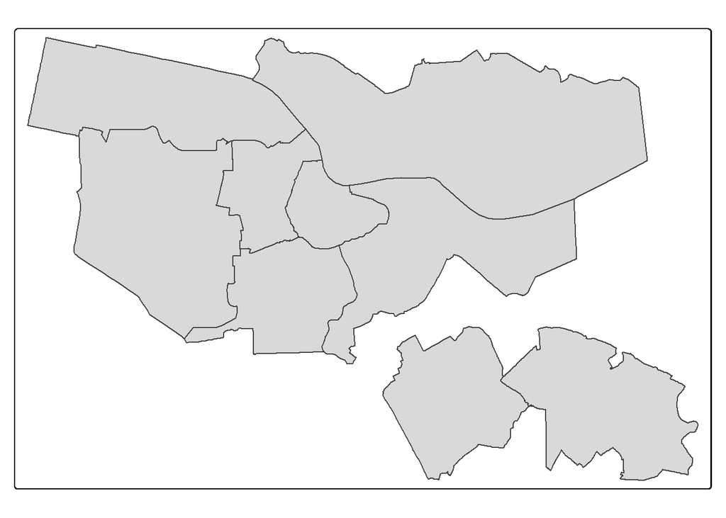

```r
amsterdam_boroughs_sf <- st_as_sf(amsterdam_boroughs_data,
                                  wkt = "WKT_LNG_LAT",
                                  crs = 4326) # Assuming WGS 84 for latitude/longitude

# Plot the spatial data to verify
qtm(amsterdam_boroughs_sf)
```

```r
crs(amsterdam_boroughs_sf)
```

```
## [1] "GEOGCRS[\"WGS 84\",\n    ENSEMBLE[\"World Geodetic System 1984 ensemble\",\n        MEMBER[\"World Geodetic System 1984 (Transit)\"],\n        MEMBER[\"World Geodetic System 1984 (G730)\"],\n        MEMBER[\"World Geodetic System 1984 (G873)\"],\n        MEMBER[\"World Geodetic System 1984 (…
```

### Berlin

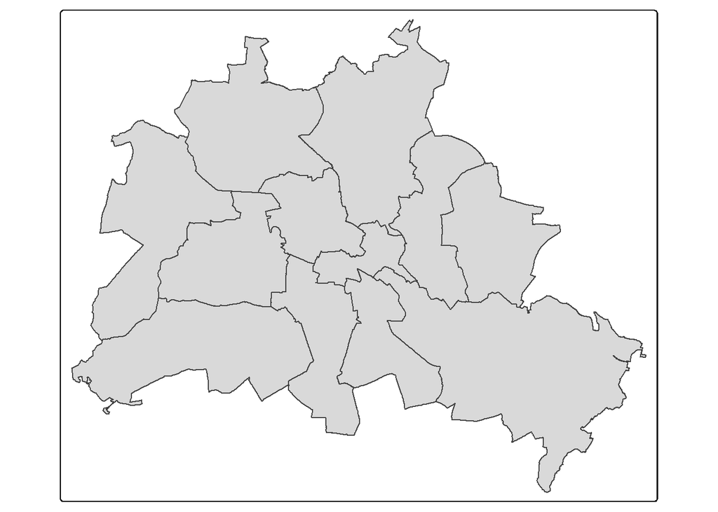

```r
qtm(berlin_boroughs)
```

# Data Check

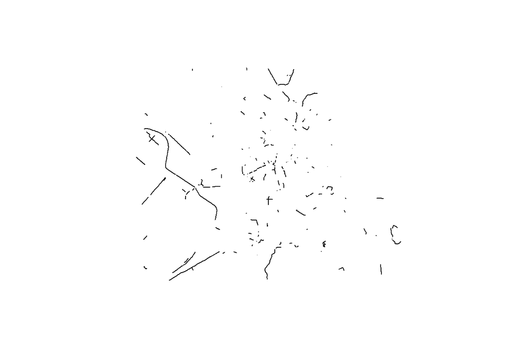

```r
plot(st_geometry(bikelane_amsterdam))
```

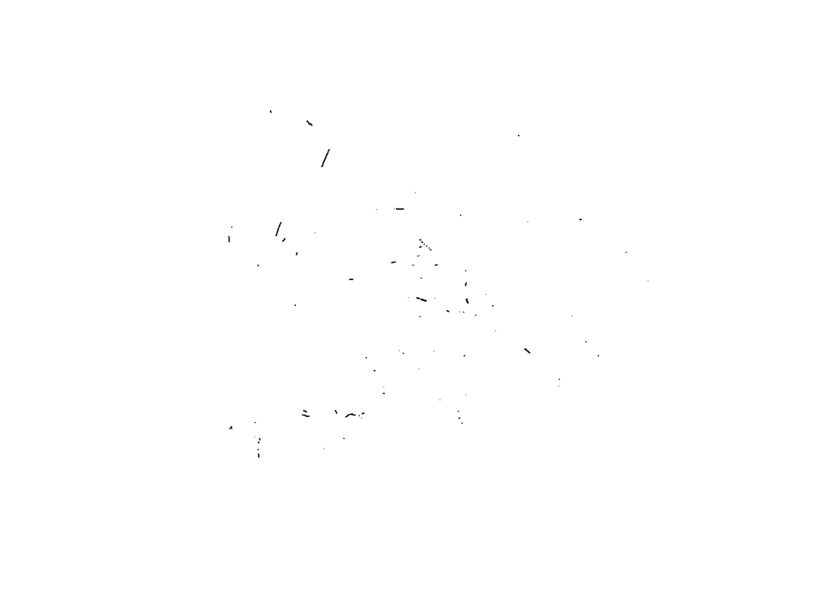

```r
plot(st_geometry(bikelane_berlin))
```

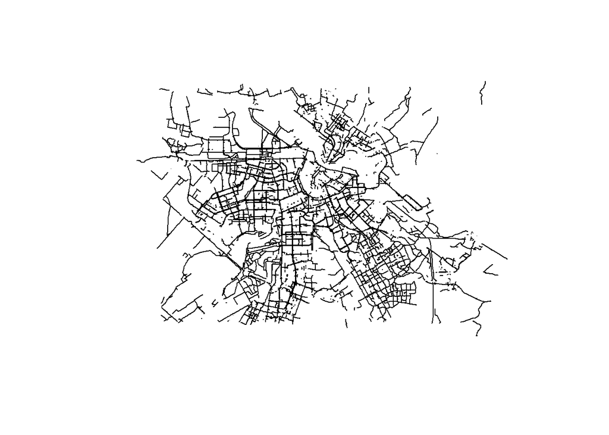

```r
plot(st_geometry(cycleway_amsterdam))
```

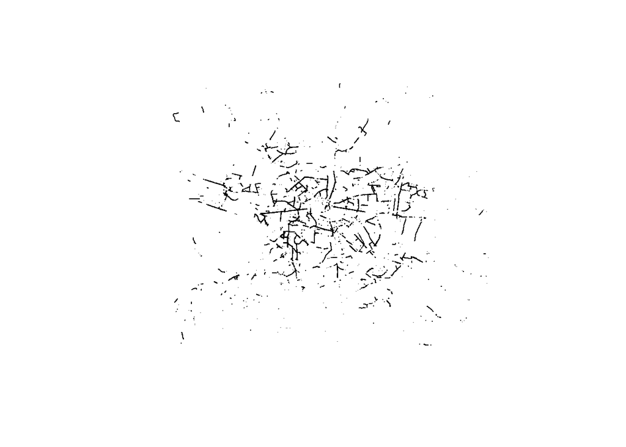

```r
plot(st_geometry(cycleway_berlin))
```

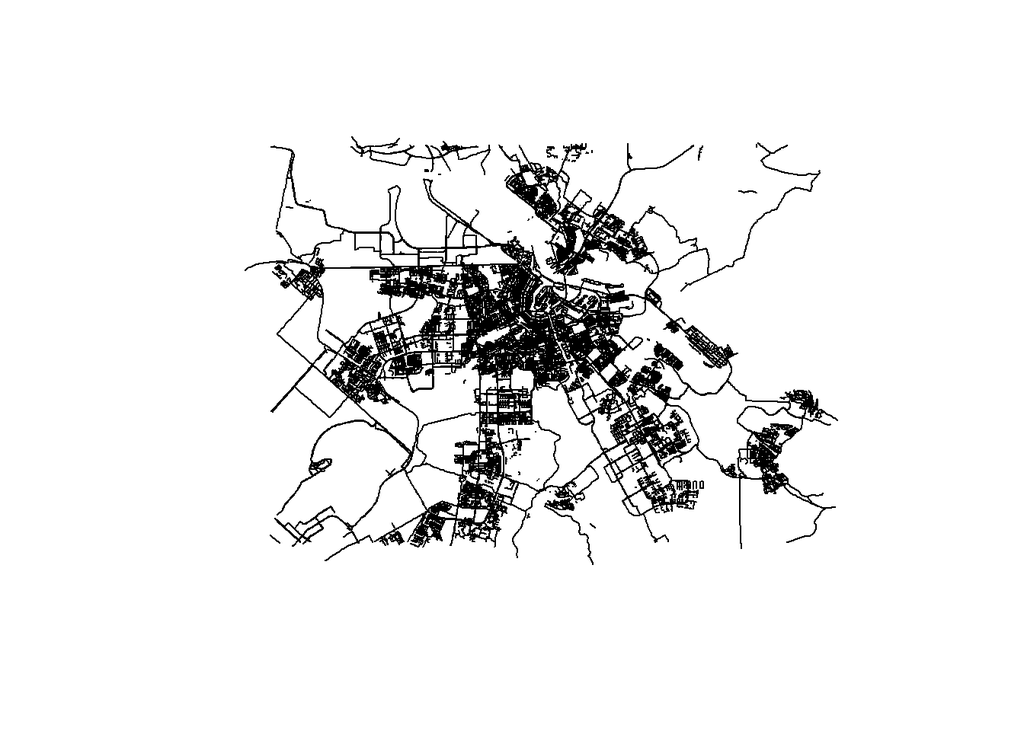

```r
plot(st_geometry(roads_amsterdam))
```

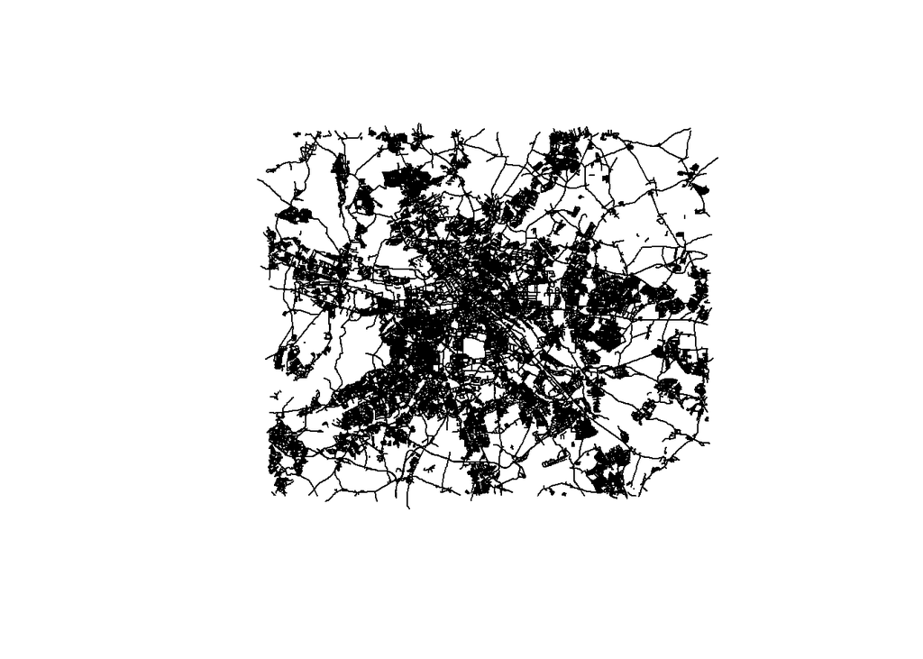

```r
plot(st_geometry(roads_berlin))
```

# Data Cleaning

## Transformation

Since the most of the files are already in the same CRS (WGS 1984), we only need to fix our Berlin.

```r
berlin_boroughs <- st_transform(berlin_boroughs, crs=st_crs(amsterdam_boroughs_sf))
```

```r
crs(berlin_boroughs)
```

```
## [1] "GEOGCRS[\"WGS 84\",\n    ENSEMBLE[\"World Geodetic System 1984 ensemble\",\n        MEMBER[\"World Geodetic System 1984 (Transit)\"],\n        MEMBER[\"World Geodetic System 1984 (G730)\"],\n        MEMBER[\"World Geodetic System 1984 (G873)\"],\n        MEMBER[\"World Geodetic System 1984 (…
```

## Joining & Processing

### Bike Lanes (attached)

Note: Running the code takes a long time so we will union all the roads (since we only want distances individual roads do not matter).

```r
bikelanes_berlin_clean <- st_union(bikelane_berlin)
bikelane_amsterdam_clean <- st_union(bikelane_amsterdam)
```

```r
# Intersect lines with borough polygons
bikelane_in_boroughs <- st_intersection(berlin_boroughs, bikelanes_berlin_clean)
# Calculate lengths
bikelane_in_boroughs <- bikelane_in_boroughs %>%
  mutate(length_m = st_length(geometry))

# Summarize lengths by borough using "gem" as the identifier
bikelane_lengths <- bikelane_in_boroughs %>%
  group_by(gem) %>%
  summarize(total_bikelane_length = sum(length_m))
```

```r
bikelane_in_boroughs_am <- st_intersection(amsterdam_boroughs_sf, bikelane_amsterdam_clean)
bikelane_in_boroughs_am <- bikelane_in_boroughs_am %>%
  mutate(length_m = st_length(WKT_LNG_LAT))

bikelane_lengths_am <- bikelane_in_boroughs_am %>%
  group_by(OBJECTNUMMER) %>%
  summarize(total_bikelane_length = sum(length_m))
```

### Cycle Lanes (separated)

```r
cycleway_berlin_clean <- st_union(cycleway_berlin)
cycleway_amsterdam_clean <- st_union(cycleway_amsterdam)
```

```r
cycleway_in_boroughs <- st_intersection(berlin_boroughs, cycleway_berlin_clean)
cycleway_in_boroughs <- cycleway_in_boroughs %>%
  mutate(length_m = st_length(geometry))

cycleway_lengths <- cycleway_in_boroughs %>%
  group_by(gem) %>%
  summarize(total_cycleway_length = sum(length_m))
```

```r
cycleway_in_boroughs_am <- st_intersection(amsterdam_boroughs_sf, cycleway_amsterdam_clean)
cycleway_in_boroughs_am <- cycleway_in_boroughs_am %>%
  mutate(length_m = st_length(WKT_LNG_LAT))

cycleway_lengths_am <- cycleway_in_boroughs_am %>%
  group_by(OBJECTNUMMER) %>%
  summarize(total_cycleway_length = sum(length_m))
```

### Roads

```r
clean_roads_berlin <- st_union(roads_berlin)
clean_roads_amsterdam <- st_union(roads_amsterdam)
```

```r
roads_in_boroughs <- st_intersection(berlin_boroughs, clean_roads_berlin)
roads_in_boroughs <- roads_in_boroughs %>%
  mutate(length_m = st_length(geometry))

roads_lengths <- roads_in_boroughs %>%
  group_by(gem) %>%
  summarize(total_road_length = sum(length_m))
```

```r
print(roads_lengths)
```

```
## Simple feature collection with 12 features and 2 fields
## Geometry type: MULTILINESTRING
## Dimension:     XY
## Bounding box:  xmin: 13.09021 ymin: 52.34225 xmax: 13.75694 ymax: 52.66043
## Geodetic CRS:  WGS 84
## # A tibble: 12 × 3
##    gem   total_road_length                                              geometry
##    <chr>               [m]                                 <MULTILINESTRING [°]>
##  1 001             371198. ((13.33358 52.56094, 13.33337 52.56106), (13.33337 5…
##  2 002             205485. ((13.4542 52.51571, 13.45431 52.5157, 13.45441 52.51…
##  3 003             608014. ((13.3726 52.59294, 13.37272 52.59293, 13.37287 52.5…
##  4 004             454504. ((13.24937 52.51535, 13.24967 52.51549, 13.2499 52.5…
##  5 005             420411. ((13.17838 52.51678, 13.17854 52.51675, 13.17861 52.…
##  6 006             629225. ((13.19781 52.43503, 13.19785 52.43508, 13.19787 52.…
##  7 007             442389. ((13.36336 52.47859, 13.3633 52.47862, 13.3625 52.47…
##  8 008             364177. ((13.42772 52.49358, 13.42768 52.49354, 13.42765 52.…
##  9 009             650557. ((13.52401 52.40534, 13.52391 52.40537, 13.52308 52.…
## 10 010             574166. ((13.51928 52.51654, 13.51935 52.51757, 13.51939 52.…
## 11 011             357270. ((13.53136 52.49263, 13.53136 52.4927, 13.53153 52.4…
## 12 012             494319. ((13.33208 52.56179, 13.33208 52.56179, 13.33201 52.…
```

```r
roads_in_boroughs_am <- st_intersection(amsterdam_boroughs_sf, clean_roads_amsterdam)
roads_in_boroughs_am <- roads_in_boroughs_am %>%
  mutate(length_m = st_length(WKT_LNG_LAT))

roads_lengths_am <- roads_in_boroughs_am %>%
  group_by(OBJECTNUMMER) %>%
  summarize(total_road_length = sum(length_m))
```

```r
print(roads_lengths_am)
```

```
## Simple feature collection with 9 features and 2 fields
## Geometry type: MULTILINESTRING
## Dimension:     XY
## Bounding box:  xmin: 4.728879 ymin: 52.27961 xmax: 5.082486 ymax: 52.43018
## Geodetic CRS:  WGS 84
## # A tibble: 9 × 3
##   OBJECTNUMMER total_road_length                                     WKT_LNG_LAT
##          <dbl>               [m]                           <MULTILINESTRING [°]>
## 1            1           136275. ((4.931267 52.37118, 4.932194 52.37172), (4.92…
## 2            2           219638. ((4.996806 52.35086, 4.997135 52.35109, 4.9971…
## 3            3            35947. ((4.739251 52.42661, 4.739329 52.42684, 4.7394…
## 4            4           285901. ((4.842482 52.38595, 4.842539 52.38598, 4.8425…
## 5            5           161150. ((4.981605 52.32576, 4.981693 52.3258, 4.98176…
## 6            6           243125. ((4.876315 52.42621, 4.876518 52.42609, 4.8767…
## 7            7           154799. ((4.87458 52.3639, 4.874636 52.36392, 4.875989…
## 8            8            91030. ((5.06472 52.29537, 5.064827 52.29539, 5.06586…
## 9            9           241485. ((4.895324 52.32241, 4.895321 52.32241, 4.8952…
```

### Joining

#### Berlin

```r
ber_roads <- roads_lengths |> pull(total_road_length)  |> set_units(km) |> round(3)
ber_cycle <- cycleway_lengths |> pull(total_cycleway_length) |> set_units(km) |> round(3)
ber_bike <- bikelane_lengths |> pull(total_bikelane_length) |> set_units(km) |> round(3)
```

```r
berlin <- berlin_boroughs
berlin$total_roads_length <- ber_roads
berlin$total_cycleway_length <- ber_cycle
berlin$total_bikelane_length <- ber_bike
```

#### Amsterdam

```r
am_roads <- roads_lengths_am |> pull(total_road_length) |> set_units(km) |> round(3)
am_cycle <- cycleway_lengths_am |> pull(total_cycleway_length)|> set_units(km) |> round(3)
am_bike <- bikelane_lengths_am |> pull(total_bikelane_length) |> set_units(km) |> round(3)
```

```r
amsterdam <- amsterdam_boroughs_sf

amsterdam$total_roads_length <- am_roads
amsterdam$total_cycleway_length <- am_cycle
amsterdam$total_bikelane_length <- am_bike
```

## Calculating Metrics

**Availability = Bicycle Traffic Roads / Car Traffic Roads**

**Quality = (Total Cycleway Length / Bicycle Traffic Roads) * 100**

```r
berlin <- berlin |> mutate(
  availability = round(((total_bikelane_length + total_cycleway_length) / total_roads_length), 2),
  quality = round((total_cycleway_length / (total_bikelane_length + total_cycleway_length)) * 100, 2)
)
```

```r
amsterdam <- amsterdam |> mutate(
  availability = round(((total_bikelane_length + total_cycleway_length) / total_roads_length), 2),
  quality = round((total_cycleway_length / (total_bikelane_length + total_cycleway_length)) * 100, 2)
)
```

# Data Visualization

This code is run so that tmap is compatible with the font I want to use.

```r
windowsFonts(`Century Gothic` = windowsFont("Century Gothic"))
```

## Availability

Bike Infrastructure Availability (per km Motor Vehicle).

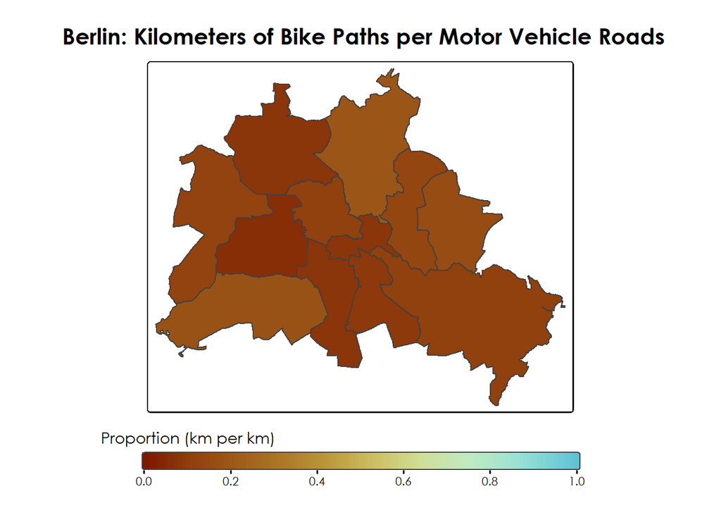

```r
ba <- tm_shape(berlin) +
  tm_polygons(
    fill = "availability",
    fill.scale = tm_scale_continuous(values = "roma",
                          limits = c(0,1),
                          midpoint = .75),
    fill.legend = tm_legend(title = "Proportion (km per km)",
                            orientation = "landscape",
                            frame = FALSE)
  ) +
  tm_title_out("Berlin: Kilometers of Bike Paths per Motor Vehicle Roads",
              fontface = "bold",
              fontfamily = "Century Gothic") +
  tm_layout(
    legend.text.fontfamily = "Century Gothic",
    legend.title.fontfamily = "Century Gothic",
    text.fontfamily = "Century Gothic"  # optional, sets global fallback
  ) +
  tmap_options(component.autoscale = FALSE)

ba
```

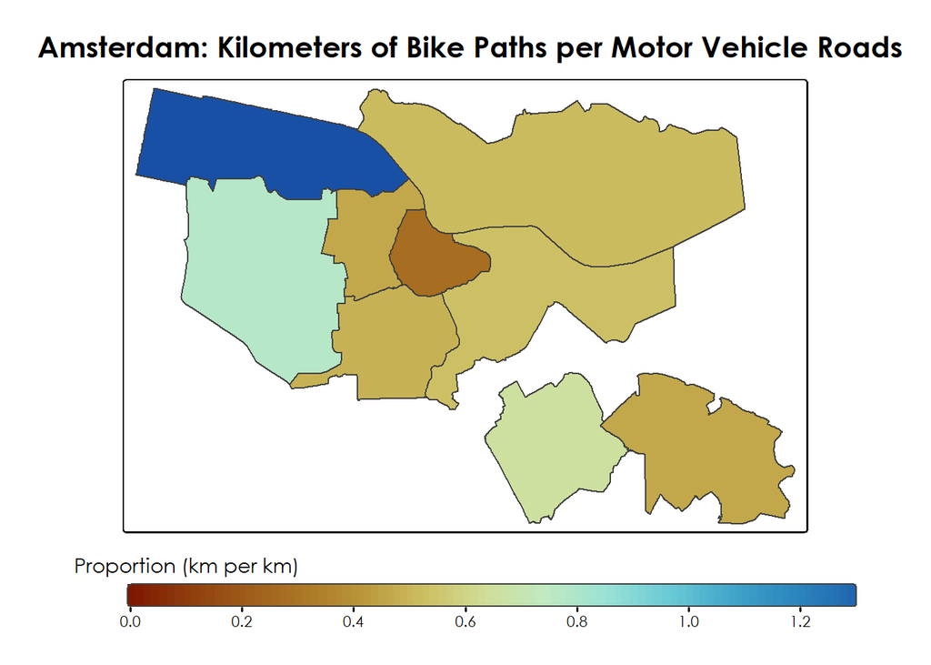

```r
aa <- tm_shape(amsterdam) +
  tm_polygons(
    fill = "availability",
    fill.scale = tm_scale_continuous(values = "roma",
                          limits = 0,
                          midpoint = .75),
    fill.legend = tm_legend(title = "Proportion (km per km)",
                            orientation = "landscape",
                            frame = FALSE)
  ) +
  tm_title_out("Amsterdam: Kilometers of Bike Paths per Motor Vehicle Roads",
              fontface = "bold",
              fontfamily = "Century Gothic") +
  tm_layout(
    legend.text.fontfamily = "Century Gothic",
    legend.title.fontfamily = "Century Gothic",
    text.fontfamily = "Century Gothic"  # optional, sets global fallback
  ) +
  tmap_options(component.autoscale = FALSE)

aa
```

## Quality

I limited the values here from 90% to 100% since this is where the values already are. This has the added benefit of making the legend uniform.

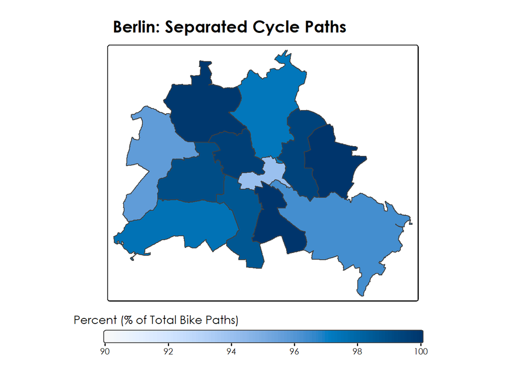

```r
bq <- tm_shape(berlin) +
  tm_polygons(
    fill = "quality",
    fill.scale = tm_scale_continuous(limits = c(90, 100)),
    fill.legend = tm_legend(title = "Percent (% of Total Bike Paths)",
                            orientation = "landscape",
                            frame = FALSE)) +
  tm_title_out("Berlin: Separated Cycle Paths",
              fontface = "bold",
              fontfamily = "Century Gothic") +
  tm_layout(
    legend.text.fontfamily = "Century Gothic",
    legend.title.fontfamily = "Century Gothic",
    text.fontfamily = "Century Gothic"  # optional, sets global fallback
  ) +
  tmap_options(component.autoscale = FALSE)

bq
```

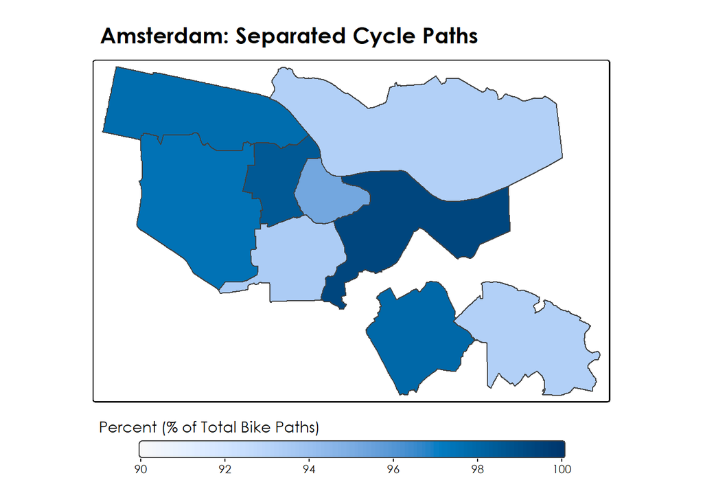

```r
aq <- tm_shape(amsterdam) +
  tm_polygons(
    fill = "quality",
    fill.scale = tm_scale_continuous(limits = c(90, 100)),
    fill.legend = tm_legend(title = "Percent (% of Total Bike Paths)",
                            orientation = "landscape",
                            frame = FALSE)) +
  tm_title_out("Amsterdam: Separated Cycle Paths",
              fontface = "bold",
              fontfamily = "Century Gothic") +
  tm_layout(
    legend.text.fontfamily = "Century Gothic",
    legend.title.fontfamily = "Century Gothic",
    text.fontfamily = "Century Gothic"  # optional, sets global fallback
  ) +
  tmap_options(component.autoscale = FALSE)

aq
```

# Saving

```r
tmap_save(ba, filename = "Assignment3/berlin_map_availability.png", width = 10, height = 8, units = "in", dpi = 300)
```

```
## Map saved to C:\Users\rafid\Documents\Hertie School\41_Geospatial_Analysis\Assignments\Assignment3\berlin_map_availability.png
```

```
## Resolution: 3000 by 2400 pixels
```

```
## Size: 10 by 8 inches (300 dpi)
```

```r
tmap_save(bq, filename = "Assignment3/berlin_map_quality.png", width = 10, height = 8, units = "in", dpi = 300)
```

```
## Map saved to C:\Users\rafid\Documents\Hertie School\41_Geospatial_Analysis\Assignments\Assignment3\berlin_map_quality.png
```

```
## Resolution: 3000 by 2400 pixels
```

```
## Size: 10 by 8 inches (300 dpi)
```

```r
tmap_save(aa, filename = "Assignment3/amsterdam_map_availability.png", width = 10, height = 8, units = "in", dpi = 300)
```

```
## Map saved to C:\Users\rafid\Documents\Hertie School\41_Geospatial_Analysis\Assignments\Assignment3\amsterdam_map_availability.png
```

```
## Resolution: 3000 by 2400 pixels
```

```
## Size: 10 by 8 inches (300 dpi)
```

```r
tmap_save(aq, filename = "Assignment3/amsterdam_map_quality.png", width = 10, height = 8, units = "in", dpi = 300)
```

```
## Map saved to C:\Users\rafid\Documents\Hertie School\41_Geospatial_Analysis\Assignments\Assignment3\amsterdam_map_quality.png
```

```
## Resolution: 3000 by 2400 pixels
```

```
## Size: 10 by 8 inches (300 dpi)
```

```r
st_write(berlin, "Assignment3/berlin_final.gpkg", append=FALSE)
```

```
## Deleting layer `berlin_final' using driver `GPKG'
## Writing layer `berlin_final' to data source
##   `Assignment3/berlin_final.gpkg' using driver `GPKG'
## Writing 12 features with 8 fields and geometry type Multi Polygon.
```

```r
st_write(amsterdam, "Assignment3/amsterdam_final.gpkg", append=FALSE)
```

```
## Deleting layer `amsterdam_final' using driver `GPKG'
## Writing layer `amsterdam_final' to data source
##   `Assignment3/amsterdam_final.gpkg' using driver `GPKG'
## Writing 9 features with 12 fields and geometry type Polygon.
```